# Project1

Wenyu

10/22/2019

## Chapter 3 States and H1B Visa Status

From the tests, we know that US states and H1B visa status are dependent on each other, therefore, we are interested to find out how the states in the U.S. are related to the H1B visa status. We are using data for both numbers of initial/continue approvals/denials and percentages of initial/continue approvals/denials in every state, this is because we found out some states not only have high numbers of approvals, but also have high numbers of denials. Hence, we used percentages to make the results more accurate.

### 3.1 SMART Question

**What is the relationship between the H1B visa approval and denial rates with the states in the U.S.?**

### 3.2 Initial Approvals

#### States VS. Numbers of Initial Approvals

```
## # A tibble: 6 x 3
## # Groups:   State [6]
##   State totalinitialapp percentiniapp
##   <chr>           <int>         <dbl>
## 1 CA             205701          89.9
## 2 NJ             161635          84.4
## 3 TX             138050          87.4
## 4 NY             103293          92.2
## 5 IL              64099          86.3
## 6 MD              54249          92.2
```

#### States VS. Percentage of Initial Approvals

```
## # A tibble: 6 x 3
## # Groups:   State [6]
##   State    percentiniapp totalinitialapp
##   <chr>            <dbl>           <int>
## 1 "\u0004"         100                 1
## 2 ID                96.2            1693
## 3 VT                95.2             917
## 4 WA                95.1           41156
## 5 RI                95.0            2282
## 6 TN                94.6           10317
```

#### **3.2.1 Map of Initial Approvals**

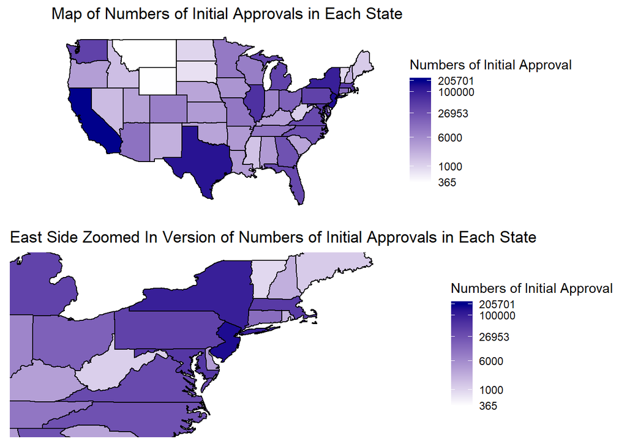

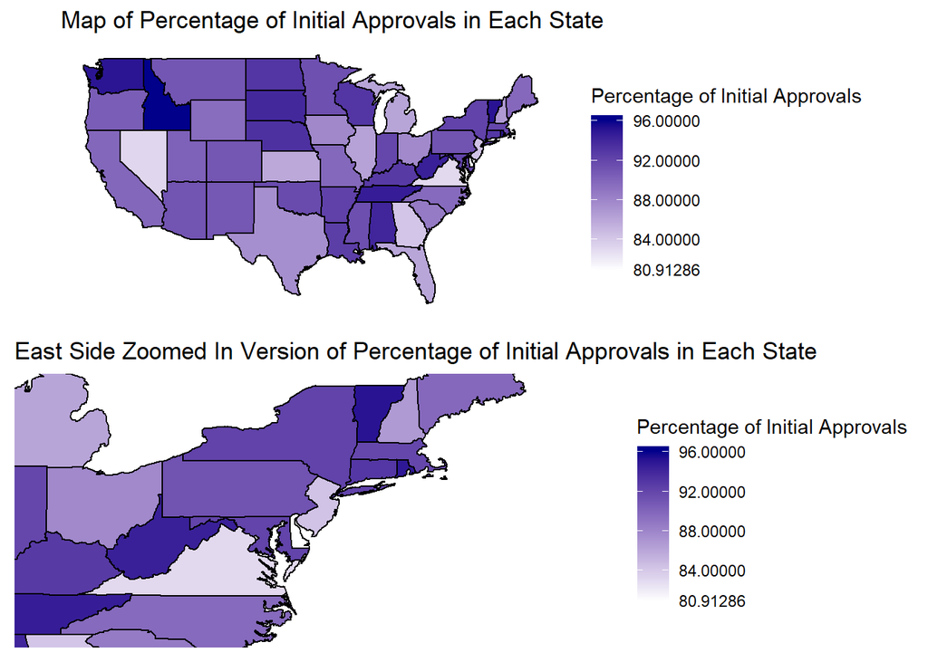

### 3.3 Initial Denials

#### **3.3.1 Maps of Initial Denials**

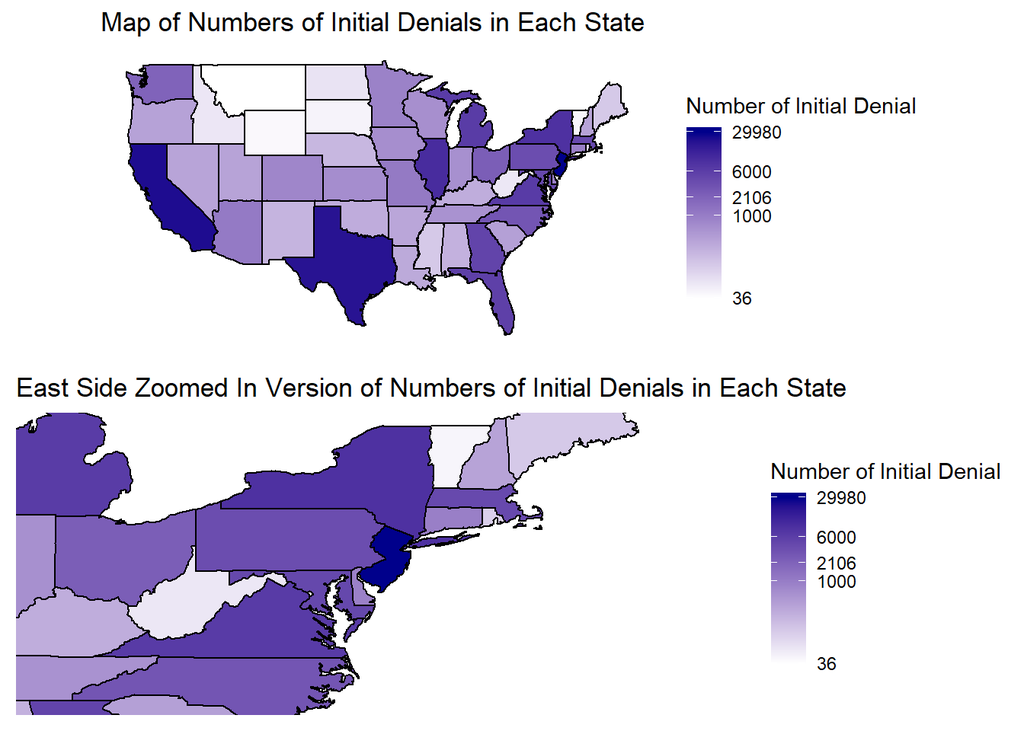

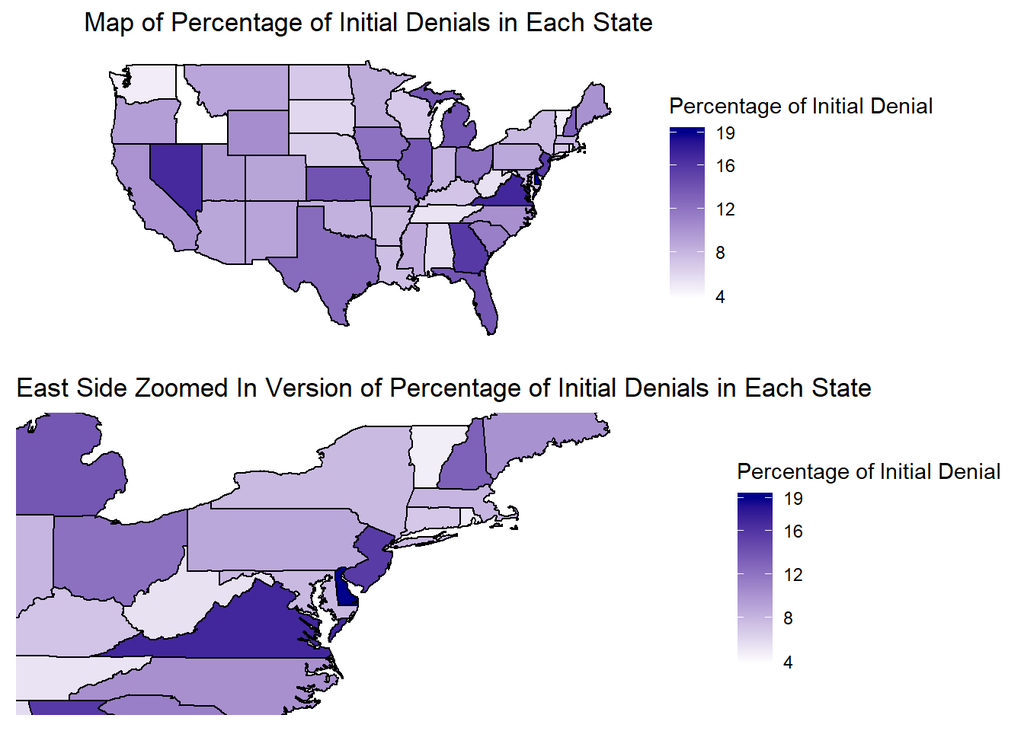

Since the values for initial denials are the conjugate of initial approvals, therefore, the rankings in the chart for lowest numbers of initial denials and lowest percentage of initial denials are the same with the charts for initial approvals.

By graphing the initial denials, we can find out which state has high initial denial rates when it has dense color in both graphs. Therefore, we notice that Virginia, New Jersey, Georgia, and Florida have relatively high initial denials rate, since they all have at least 6000 numbers of initial denials and around 16% of initial denials.

### 3.4 Continue Approvals

#### States VS. Numbers of Continue Approvals

```
## # A tibble: 5 x 3
## # Groups:   State [5]
##   State totalcontapp percentcontapp
##   <chr>        <int>          <dbl>
## 1 CA          348892           95.9
## 2 TX          303902           92.9
## 3 NJ          252741           92.9
## 4 NY          144770           96.3
## 5 IL          110919           93.7
```

#### States VS. Percentage of Continue Approvals

```
## # A tibble: 9 x 3
## # Groups:   State [9]
##   State percentcontapp totalcontapp
##   <chr>          <dbl>        <int>
## 1 AE             100              5
## 2 AP             100              1
## 3 FM             100              1
## 4 ""              98.6          139
## 5 VT              98.1         2278
## 6 WA              97.3        67298
## 7 SD              97.2          827
## 8 MS              97.1         1805
## 9 RI              97.1         5484
```

From the tables, we notice that California, Texas, New Jersey, New York, and Illinois have high numbers of continue approvals, and they also have a relatively high percentage of continue approval. This might be due to the policy that continue approval exists if and only if the person has the initial approval for an H1B visa, therefore, the success rate for obtaining a continued approval for an H1B visa is higher than an initial approval.

In the percentage chart, “AE, AP, FM” are U.S. military code, and the blank states are the provinces in Canada, therefore, we can ignore the top four rankings. Vermont, Washington, South Dakota, Mississippi, and Rhode Island are the top five states that have a high percentage rate in continue approvals. However, their numbers of continue approvals are in big difference as well, therefore, it’s better to plot them on a map to visualize them better.

#### **3.4.1 Map of Continue Approvals**

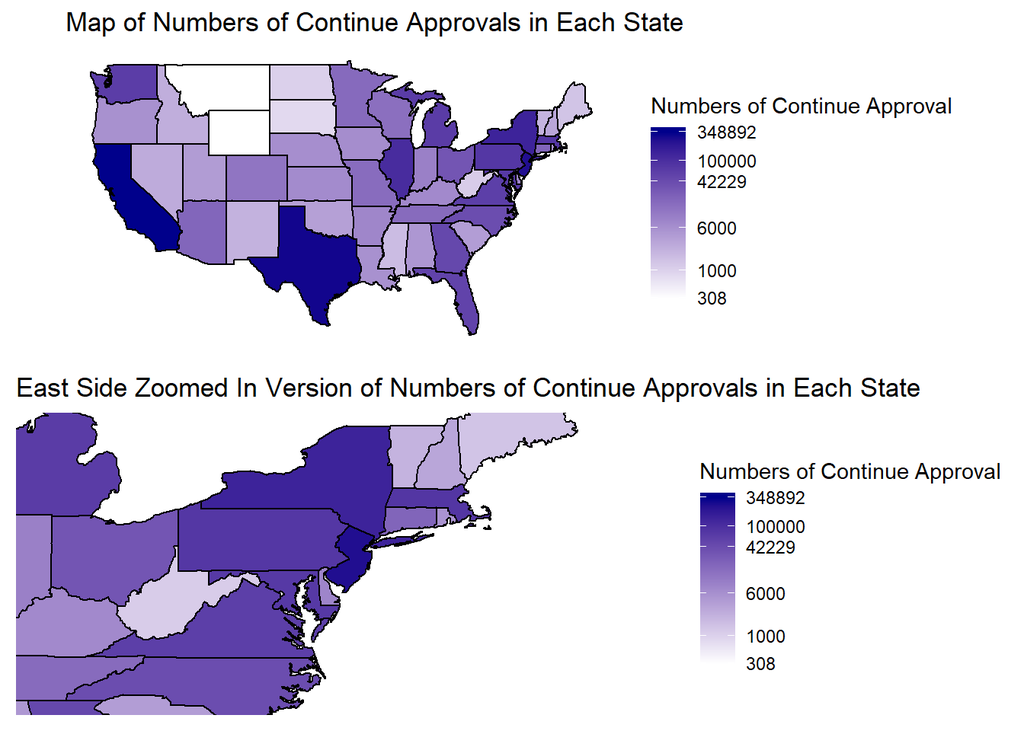

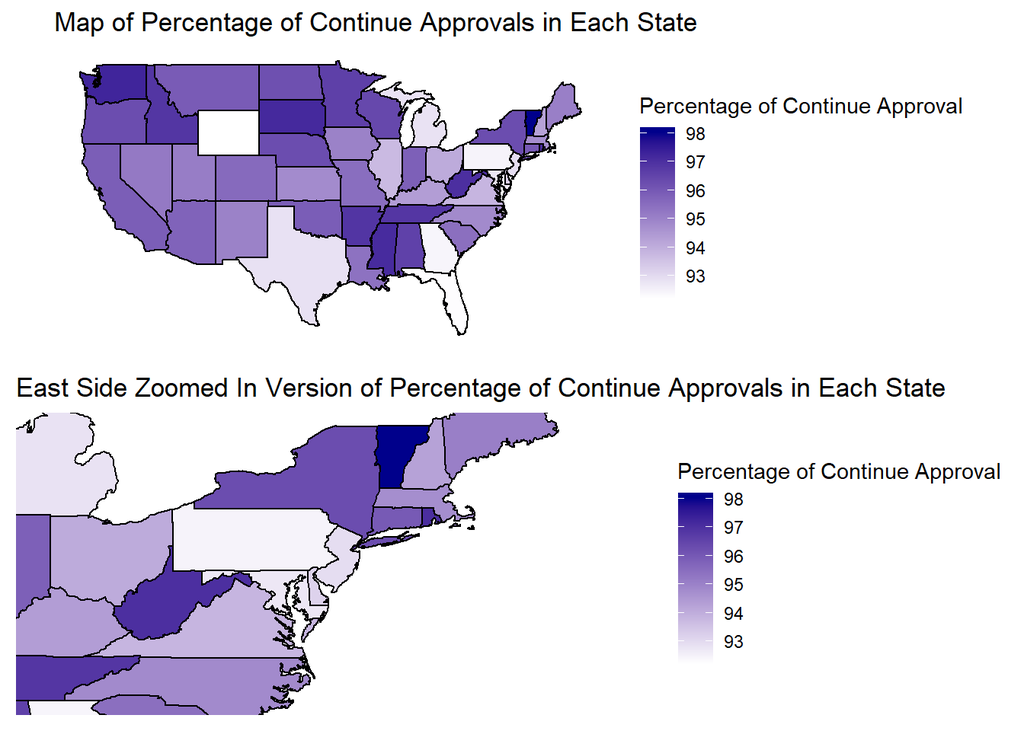

From the graphs, we can see that Washington, California, and New York states have dense color in both graphs, they all have at least 67,000 number of continuing approvals, and at least 95% of continue approval rates.

### 3.5 Continue Denials

#### **3.5.1 Map of Continue Denials**

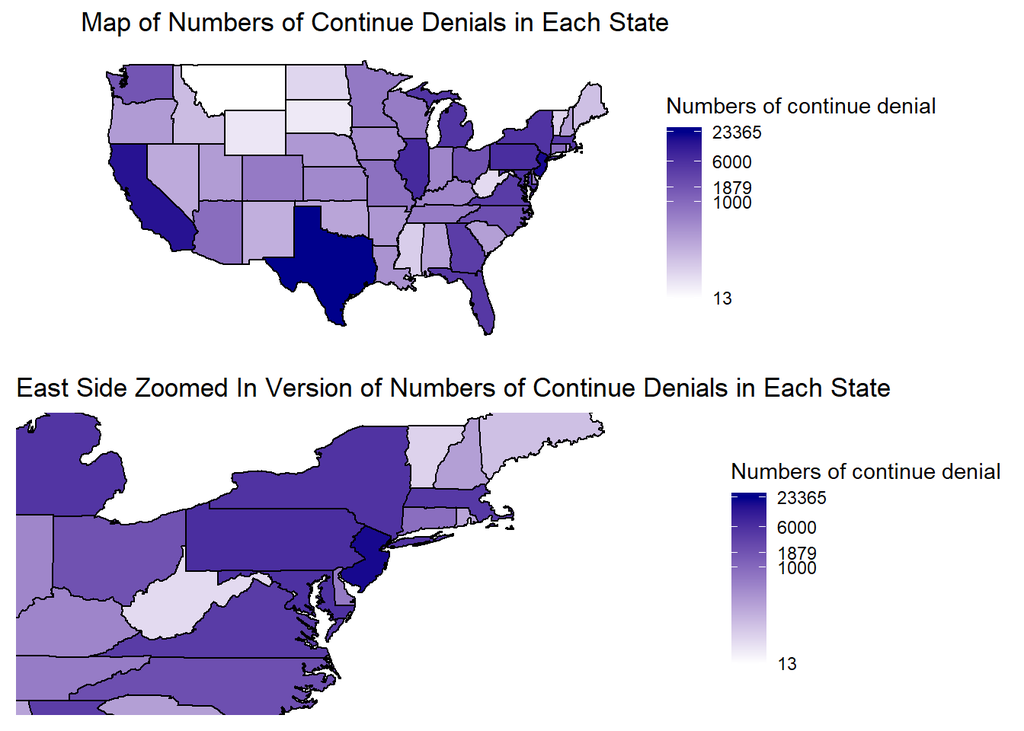

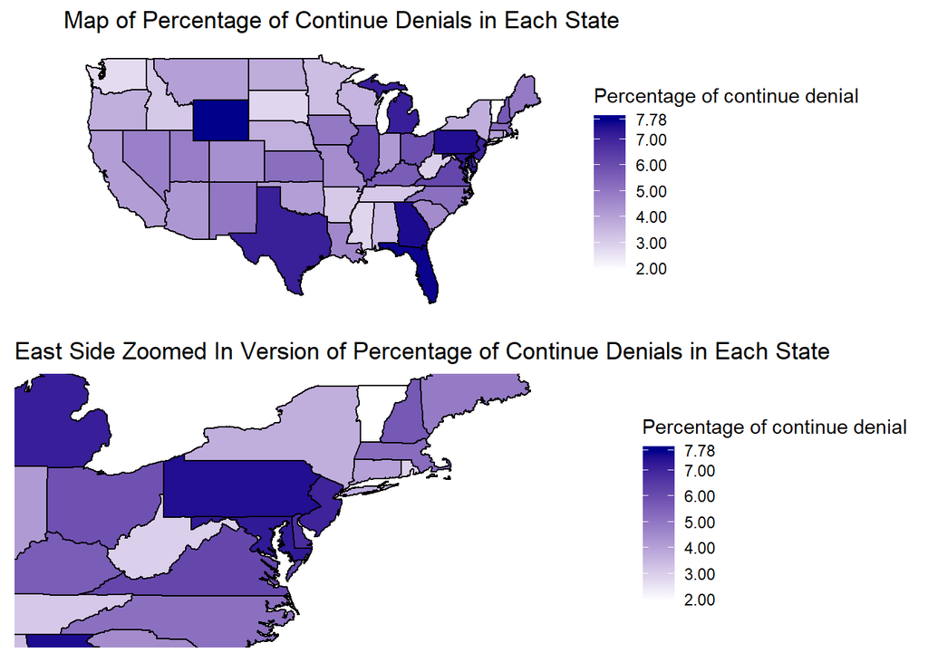

Same as initial denials, the lowest number of continue denials and lowest percentage of continue denials are the same with continue approvals, because the number of continue denials is the conjugate of the number of continue approvals.

```
## # A tibble: 5 x 3
## # Groups:   State [5]
##   State percentcontden totalcontden
##   <chr>          <dbl>        <int>
## 1 PA              7.52         6578
## 2 MD              7.27         6018
## 3 TX              7.14        23365
## 4 NJ              7.05        19172
## 5 IL              6.27         7421
```

Through the table, we can see Pennsylvania, Maryland, Texas, New Jersey and Illinois have high continue denial rates, since they all have at least 6,000 number of continue denials, and above 6% of continue denials.